# Building KNN classifier

Wasnik Malla

24 January 2021

## R Markdown

**Initialising packages**

```r
#install.packages("reshape2")
#install.packages("ggplot2")
#install.packages("corrplot")
#install.packages("Cairo")
#install.packages("glmnet")

library(glmnet)
library(reshape2)
library(ggplot2)
library(corrplot)
```

**We are implementing a KNN classifier to predict the class of iris plants. The well-known iris dataset is used in this question. Detailed description of this data set can be found at https://archive.ics.uci.edu/ml/datasets/iris.**

Specifically, we need to:

1. Split the data set into a training and a test set with the ratio of 7:3
2. Implement a KNN classifier.
3. Investigate the impact of different K (from 1 to 6) values on the model performance (ACC) and the impact of different distance measurements (euclidean, manhattan, canberra, and minkowski) on the model performance (ACC). Visualize and discuss your findings.

**1. Split the data set into a training and a test set with the ratio of 7:3**

```r
#loading iris data set
iris <- read.csv(url("http://archive.ics.uci.edu/ml/machine-learning-databases/iris/iris.data"))
```

```r
#checking dataframe structure
data(iris) # loading to dataframe

head(iris)
```

```
##   Sepal.Length Sepal.Width Petal.Length Petal.Width Species
## 1          5.1         3.5          1.4         0.2  setosa
## 2          4.9         3.0          1.4         0.2  setosa
## 3          4.7         3.2          1.3         0.2  setosa
## 4          4.6         3.1          1.5         0.2  setosa
## 5          5.0         3.6          1.4         0.2  setosa
## 6          5.4         3.9          1.7         0.4  setosa
```

Now let us find out how our data is distributed / scattered among groups within different class labels.

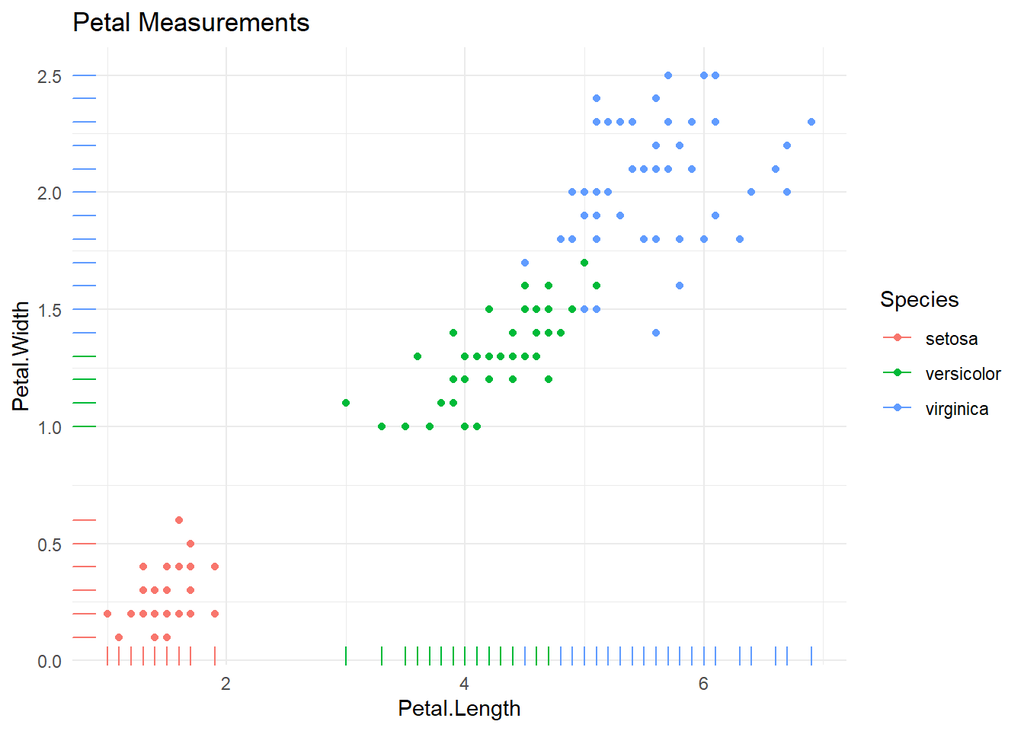

```r
## the followin plot illustrates petal measurments:

ggplot(data=iris, aes(x=Petal.Length, y=Petal.Width, color=Species)) +
    geom_point() + geom_rug()+ theme_minimal() + ggtitle("Petal Measurements")
```

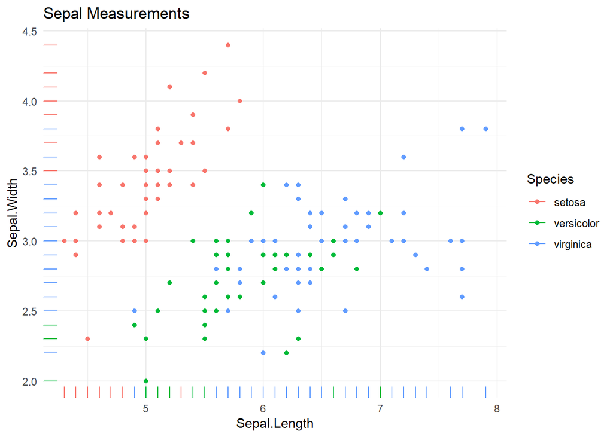

```r
# this plot illustrates sepal measurement
ggplot(data=iris, aes(x=Sepal.Length, y=Sepal.Width, color=Species)) +
    geom_point() + geom_rug()+ theme_minimal() + ggtitle("Sepal Measurements")
```

From above plots what we can seen in petal meausrements, there are three distinct groups, where Setosa falls within first quadrant close to 2 and 0, as length and width increases, Versicolor and Virginica are clustered separately.

Now, looking at Sepal measurements, Setosa are distinct than other two, whereas Versicolor and Virginica are mostly mixed.

In other words, what we can say is, petal measurements are best utilised for clusturing problem and KNN would be best applied for both clustering and classification problem.

**Normalisation**

Now let us normalize iris data sets before splicing into training and test sets to 7:3 ratio.

```r
# normalise function created as below -

norm <- function(x) {

  return ((x - min(x)) / (max(x) - min(x)))

}

#applying normalization to data frame

iris.norm <- as.data.frame(lapply(iris[, c(1,2,3,4)], norm))
iris.norm <- cbind(iris.norm, iris[, 5]) # binding Species feature to normalised dataframe
colnames(iris.norm)[5] <-  c("Species") # renaming column

head(iris.norm) # checking
```

```
##   Sepal.Length Sepal.Width Petal.Length Petal.Width Species
## 1   0.22222222   0.6250000   0.06779661  0.04166667  setosa
## 2   0.16666667   0.4166667   0.06779661  0.04166667  setosa
## 3   0.11111111   0.5000000   0.05084746  0.04166667  setosa
## 4   0.08333333   0.4583333   0.08474576  0.04166667  setosa
## 5   0.19444444   0.6666667   0.06779661  0.04166667  setosa
## 6   0.30555556   0.7916667   0.11864407  0.12500000  setosa
```

Now we are going to split training and test set from new normalized dataframe called iris.norm

**Split**

```r
set.seed(123)

train.index <- sample(1:nrow(iris.norm), 0.7 * nrow(iris.norm))

#extracting training set leaving categorical index out of data set
train.data <- iris.norm [train.index, -5]

#head(train.data)
#dim(train.data)

# extracting labels only for training data set
train.label <- iris.norm[train.index, 5]

#head(train.label)

# extracting test data set
test.data <- iris.norm[-train.index, -5]

#dim(test.data)

# extracting label for test set to compare accuracy
test.label <- iris.norm[-train.index, 5]

#head(test.label)
```

**2. Implement a KNN classiﬁer**

```r
# define an auxiliary function that calculates the majority votes (or mode!)

majority <- function(x) {
   uniqx <- unique(x)
   uniqx[which.max(tabulate(match(x, uniqx)))]
}
```

**building KNN function**

```r
# KNN function (distance should be one of euclidean, manhattan, canberra, and minkowski)

knn <- function(train.data, train.label, test.data, K, distance){

    ## count number of train samples
    train.len <- nrow(train.data)

    ## count number of test samples
    test.len <- nrow(test.data)

    ## calculate distances between samples
    dist <- as.matrix(dist(rbind(test.data, train.data), method= distance))[1:test.len, (test.len+1):(test.len+train.len)]

    ## for each test sample...
    for (i in 1:test.len){
        ### ...find its K nearest neighbours from training sampels...
        nn <- as.data.frame(sort(dist[i,], index.return = TRUE))[1:K,2]

        ###... and calculate the predicted labels according to the majority vote
        test.label[i]<- (majority(train.label[nn]))
    }

    ## return the class labels as output
    return (test.label)
}
```

**3. Investigate the impact of diﬀerent K (from 1 to 6) values on the model performance (ACC) and the impact of diﬀerent distance measurements (euclidean, manhattan, canberra, and minkowski) on the model performance (ACC)**

Lets build this functin to calculate each distanance from k = 1 to 6.

```r
# creating function to calculate accuracy
accuracy <- function(x) {
  round(sum(diag(x) / sum(rowSums(x))) * 100, 2)
}


# building function to see the impact of K between 1 to 6

impact <- function(distance) {

  k <- c(1,2,3,4,5,6)

  accuracy.list <- c()

  for (i in k) {

    # calling function for prediction
    pred <- knn(train.data, train.label, test.data, i, distance)

    # generating confusion matrix
    confusion.matrix <- prop.table(table(pred, test.label))*100

    # calculating accuracy by calling function defined before
    ACC <- accuracy(confusion.matrix)

    accuracy.list[i] <- ACC # appending accuracy for k = 1 to 6

  }

  df <- as.data.frame(accuracy.list) # creating dataframe of list of accuracy
  names(df) <- 'Accuracy'
  #print(df)

  ggplot(df, aes(x=rownames(df), Accuracy)) + ggtitle(paste0("Accuracy for different values of K using distance =", distance)) + geom_bar(stat = 'identity', width= 0.5, fill= "Steelblue") + xlab("Value of K") + geom_text(aes(label=Accuracy), vjust= 1.6, color="white", size=3.5) + theme_minimal()

}
```

Now after a function is created to find the impact on prediction for different value of K, we will now call the function for each distace as asked, where distance is the argument for the function, as such -

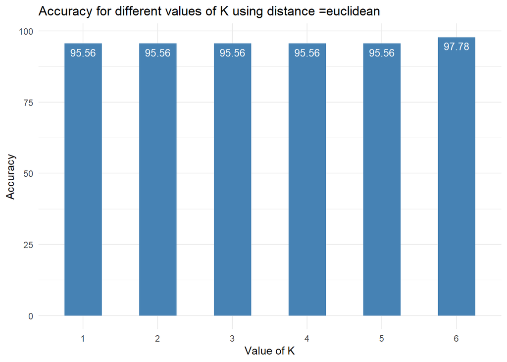

```r
# calling function for each distance

impact('euclidean')
```

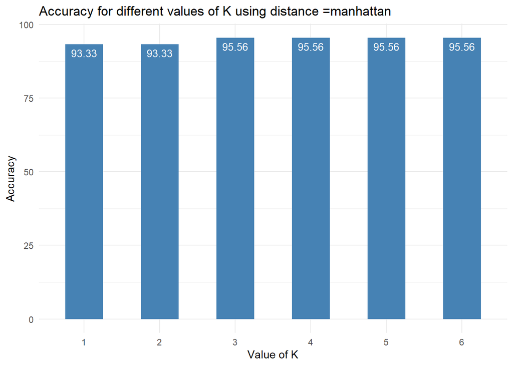

```r
impact('manhattan')
```

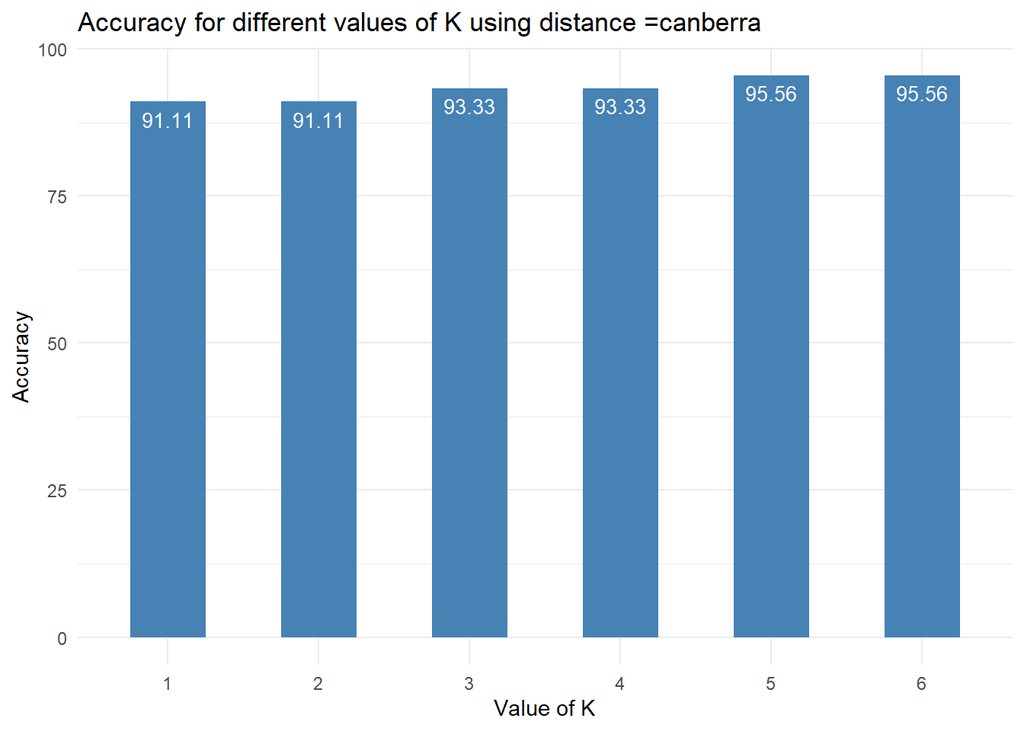

```r
impact('canberra')
```

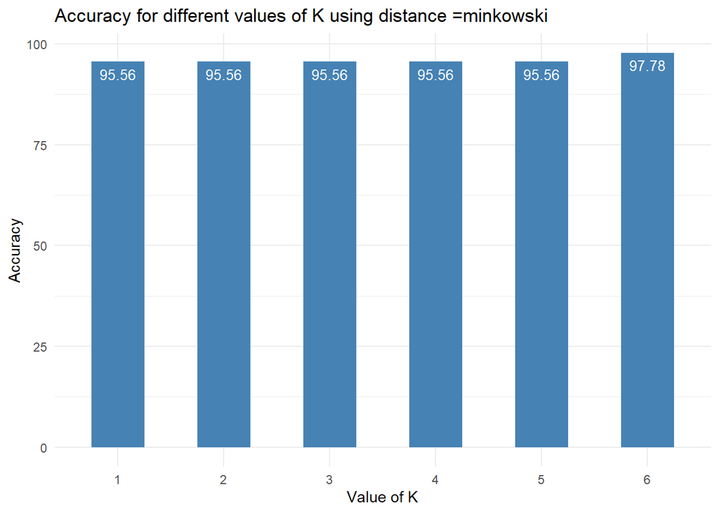

```r
impact('minkowski')
```

As we can see from above plots, the accuracy of prediction for each distance measurement for the value of K from 1 to 6.

For euclidean distance, accuracy is similar upto k=5, which is at 95.56%, wehreas, k=6 yields 97.78% For manhattan distance, maximum accuracy obtained is 95.56% for k = 3,4,5 and 6. For canberra distance, accuracy increases as K increases, maximum accuracy at 95.56% for K = 5 and 6. For Minkowski distnce, maximum accuracy is 97.78% for K = 6.

From the above trend, distance measurement for Euclidean adn Minkowski, we have same trend,

Thus we can select our best model as per the findings, whcis is one of two:

1, Euclidean distnce with K=6

2. Minkowsi distance with K = 6